```python
from IPython.html.services.config import ConfigManager
from IPython.utils.path import locate_profile
cm = ConfigManager(profile_dir=locate_profile(get_ipython().profile))
cm.update('livereveal', {
              'theme': 'simple_cyr',
              'transition': 'zoom',
              'start_slideshow_at': 'selected',
              'height': '724',
              'scroll': True,
              'slideNumber': True
})
```

```
C:\Program Files\Anaconda3\lib\site-packages\IPython\utils\path.py:283: UserWarning: locate_profile has moved to the IPython.paths module
  warn("locate_profile has moved to the IPython.paths module")
```

```
{'fontsize': '5',
 'height': '724',
 'minScale': '0.8',
 'scroll': True,
 'slideNumber': True,
 'start_slideshow_at': 'selected',
 'theme': 'simple_cyr',
 'transition': 'zoom'}
```

# Методы Оптимизации. Даниил Меркулов. Введение.

## Структура курса и семинаров

- Годовой курс. Осенний семестр теоретический. Весенний - практический.
- Экзамен после обоих семестров.
- *Лекции* по средам в 10.45; *Семинары* по вторникам в 17.05 907 КПМ
- На семинаре: краткий письменный опрос по материалам предыдущего семинара, обзор необходимой теории, решение задач, сдача домашнего задания

## Расписание (примерное)

- Неделя 1. Введение
- Неделя 2. Выпуклость. Выпуклое множество
- Неделя 3. Проекция точки на множество. Отделимость
- Неделя 4. Сопряженные множества. Лемма Фаркаша
- Неделя 5. Векторное дифференцирование
- Неделя 6. Выпуклые функции. Задачи выпуклого программирования
- Неделя 7. Субдифференциал
- Неделя 8. Промежуточная контрольная
- Неделя 9. Конус возможных направлений, касательный конус, острый экстремум
- Неделя 10. Сопряжённые функции
- Неделя 11. Условия оптимальности
- Неделя 12. Двойственная задача
- Неделя 13. Задача аппроксимации
- Неделя 14. Задачи линейной алгебры
- Неделя 15. Контрольная/ сдачи/ резерв

## Приём домашнего задания

- Домашнее задание оформляется в $ \LaTeX $ или `jupyter`. Другие формы (листочки, сканы тетрадки и пр.) не принимаются :(
- Задание отправляется **единым** файлом (форматы: `.pdf`, `.ipynb`, `.zip`, `.rar`) боту в telegram: https://t.me/optimization_hw_bot
- Возможно внесение исправлений/правок в отправленное дз. Тогда оно будет датироваться **последней** отправкой
- Каждое дз необходимо защитить устно, после чего за него будет выставлена оценка. Возможности для устной сдачи: Вторник 18.30 - 20.00. В любой другой день в Skoltech по предварительной договоренности.
- Дедлайны по каждой домашке: 1-ый до начала следующего семинара, 2-ой до конца следующей недели. После 1-ого и до 2-го дедлайнов дз стоит 80 % исходной цены, после 2-ого дедлайна дз стоит 50% исходной цены.

## Система оценивания

[figure not shown]

## Система анонимного фидбека

- После каждого семинара в канале публикуется ссылка с опросом о прошедшем семинаре. Это очень важно, оставьте пару комментариев - это анонимно. https://t.me/mipt_optimization

## Материалы

### Оптимизация

1. [Stephen Boyd, Lieven Vandenberghe. Convex Optimization](https://web.stanford.edu/~boyd/cvxbook/bv_cvxbook.pdf)
2. [Курс по выпуклой оптимизации в Stanford'e](https://web.stanford.edu/class/ee364a/)
3. [Курс по оптимизации L. Vandenberghe в UCLA](http://www.seas.ucla.edu/~vandenbe/ee236b/ee236b.html)
4. [Материалы по оптимизации А.Катруцы ФУПМ МФТИ](https://github.com/amkatrutsa/MIPT-Opt)
5. [Ю.Е. Нестеров. Методы выпуклой оптимизации](http://premolab.ru/pub_files/pub5/MnexoB89z7.pdf)
6. [Б.Т. Поляк. Введение в оптимизацию](https://mega.nz/#!fctUlQoZ!id1FfSYuJKZJPP8xrpR1lnfW4HhC8NJhbN0wyO_5S3I)
7. [Видео лекций S. Boyd'a по курсу Convex Optimization в Stanford'е](https://www.youtube.com/watch?v=McLq1hEq3UY&list=PL3940DD956CDF0622)
8. [Миникурс по выпуклой оптимизации от S. Boyd'a](http://stanford.edu/~boyd/papers/cvx_short_course.html)
9. [Convex Optimization: Algorithms and Complexity by S. Bubeck](https://mega.nz/#!CVcxyDCY!225VpAG7KC9V4wZ3zPwDUEotaw1pvnD9ArL6uVmLhB0)
10. [Matrix Cookbook](https://www.math.uwaterloo.ca/~hwolkowi/matrixcookbook.pdf)

## Примеры задач оптимизации или чего можно достичь, изучая этот дивный мир

### Искусственный интеллект. Машинное обучение

[figure not shown]

### Задача выбора портфолио

- Переменные - количество денег, инвестируемых в конкретный актив
- Ограничения - бюджет, min/max необходимое количество инвестиций в актив(ы)
- Минимизируемый функционал: общий риск или дисперсия оценки возвращенных средств

### Индустрия мультипликации

### Общая математическая формулировка

$$\text{minimize } f_0(x)$$$$\text{subject to } f_i(x) \le b_i, i = 1, \ldots, m$$

- $x = (x_1, \ldots, x_n)$: оптимизируемые параметры (переменные)
- $f_0: \mathbf{R}^n \rightarrow \mathbf{R}$: целевая функция
- $f_i: \mathbf{R}^n \rightarrow \mathbf{R}, i = 1, \ldots, m$: ограничения

Решение $x^*$ доставляет наименьшее значение функции $f_0(x)$ среди всех $x$, удовлетворяющих ограничениям

### История и текущее положение дел

#### Теория

- 1900 - 1970: выпуклый анализ
- 1933+ : теория вероятностей, математическая статистика

[figure not shown]

#### Методы

- 1947: Симплексный метод решения задач линейного программирования (Данциг)
- 1960-ые: Методы внутренней точки
- 1970-ые: Метод эллипоидов. Субградиентные методы
- 1980-ые: Методы внутренней точки, работающие за полиномиальное время для линейного программирования
- 1987+ : Методы внутренней точки для нелинейной выпуклой оптимизации (Немировский, Нестеров)
- 2000+ : Стохастические алгоритмы невыпуклой оптимизации

#### Приложения

- до 1990: в основном, исследование операций
- после 1990: бурное развитие приложений, обработка сигналов, разработка схем
- 2007+ : нейронные сети

## Пример решения задачи оптимизации с помощью геометрической интерпретации

### Пример 1

$\text{extr}\left(x_1 + x_2\right)$ при условии $x_1^2 + 4x_2^2 \le 4$

### Пример 2

$\text{extr}\left(\left|x_1\right|^\lambda + 2 \left|x_2\right|^\lambda \right)$ при условии $x_1^2 + 4x_2^2 \le 4, \;\; \lambda \neq 0$

```python
import plotly
import plotly.plotly as py
import plotly.graph_objs as go

import pandas as pd
plotly.offline.init_notebook_mode(connected=True)

# Read data from a csv
z_data = pd.read_csv('https://raw.githubusercontent.com/plotly/datasets/master/api_docs/mt_bruno_elevation.csv')

data = [
    go.Surface(
        z=z_data.as_matrix()
    )
]
layout = go.Layout(
    title='Mt Bruno Elevation',
    autosize=False,
    width=500,
    height=500,
    margin=dict(
        l=65,
        r=50,
        b=65,
        t=90
    )
)
fig = go.Figure(data=data, layout=layout)
plotly.offline.iplot(fig, filename='elevations-3d-surface')
```

[interactive chart not shown]

```python
import plotly
import plotly.plotly as py
from plotly.graph_objs import *
import plotly.graph_objs as go

import numpy as np
plotly.offline.init_notebook_mode(connected=True)

t = np.linspace(0, np.pi, 240)
tGrid, sGrid = np.meshgrid(s, t)

r = 1  # r = 2 + sin(7s+5t)
x = r * np.sin(tGrid)  # x = r*cos(s)*sin(t)
y = r * np.cos(tGrid)  # y = r*sin(s)*sin(t)
z = 0                 # z = r*cos(t)

surface = Surface(x=x, y=y, z=z)
data = Data([surface])

x1 = np.linspace(-2,2)
x2 = np.linspace(-2,2)
f = np.zeros((len(x1), len(x2)))

for i in range(len(x1)):
    for j in range(len(x2)):
        f[i][j] = x1[i]+ x2[j]

# xx, yy = np.mgrid[:200, :200]/200
# circle = (xx) ** 2 + (yy) ** 2

target_function = go.Surface(x = x1, y = x2, z=f)
constraint = go.Surface(x=0, y=0, z=0)

data_ = [target_function, constraint]



layout = Layout(
    title='Пример 1',
    scene=Scene(
        xaxis=XAxis(
            gridcolor='rgb(255, 255, 255)',
            zerolinecolor='rgb(255, 255, 255)',
            showbackground=True,
            backgroundcolor='rgb(230, 230,230)'
        ),
        yaxis=YAxis(
            gridcolor='rgb(255, 255, 255)',
            zerolinecolor='rgb(255, 255, 255)',
            showbackground=True,
            backgroundcolor='rgb(230, 230,230)'
        ),
        zaxis=ZAxis(
            gridcolor='rgb(255, 255, 255)',
            zerolinecolor='rgb(255, 255, 255)',
            showbackground=True,
            backgroundcolor='rgb(230, 230,230)'
        )
    )
)

fig = Figure(data=data_, layout=layout)
plotly.offline.iplot(fig, filename='jupyter/parametric_plot')
```

[interactive chart not shown]

```python
import plotly.plotly as py
import plotly.graph_objs as go
plotly.offline.init_notebook_mode(connected=True)

import numpy as np


s = np.linspace(0, 2 * np.pi, 240)
t = np.linspace(0, 2*np.pi, 240)
st, t = np.meshgrid(s, t)

r =  np.meshgrid(np.linspace(0,1,240), np.linspace(0,1,240))[0]
x = r * np.cos(t)# * np.sin(tGrid)  # x = r*cos(s)*sin(t)
y = r *np.sin(t)# * np.sin(tGrid)  # y = r*sin(s)*sin(t)
z = np.zeros((240,240))
surface = go.Surface(x=x, y=y, z=z)

x1 = np.linspace(-2,2)
x2 = np.linspace(-2,2)
f = np.zeros((len(x1), len(x2)))

for i in range(len(x1)):
    for j in range(len(x2)):
        f[i][j] = x1[i]+ x2[j]

# xx, yy = np.mgrid[:200, :200]/200
# circle = (xx) ** 2 + (yy) ** 2

target_function = go.Surface(x = x1, y = x2, z=f)

data = [surface, target_function]

layout = go.Layout(
    title='Parametric Plot',
    scene=dict(
        xaxis=dict(
            gridcolor='rgb(255, 255, 255)',
            zerolinecolor='rgb(255, 255, 255)',
            showbackground=True,
            backgroundcolor='rgb(230, 230,230)'
        ),
        yaxis=dict(
            gridcolor='rgb(255, 255, 255)',
            zerolinecolor='rgb(255, 255, 255)',
            showbackground=True,
            backgroundcolor='rgb(230, 230,230)'
        ),
        zaxis=dict(
            gridcolor='rgb(255, 255, 255)',
            zerolinecolor='rgb(255, 255, 255)',
            showbackground=True,
            backgroundcolor='rgb(230, 230,230)'
        )
    )
)

fig = go.Figure(data=data, layout=layout)
plotly.offline.iplot(fig, filename='jupyter/parametric_plot')
```

[interactive chart not shown]

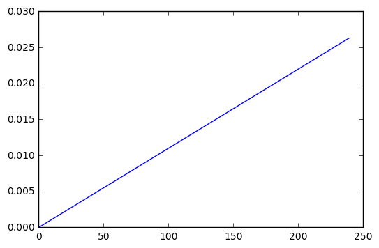

```python
plt.plot(y[1])
```

```python
plotly.offline.init_notebook_mode(connected=True)
z1 = [
    [8.83,8.89,8.81,8.87,8.9,8.87],
    [8.89,8.94,8.85,8.94,8.96,8.92],
    [8.84,8.9,8.82,8.92,8.93,8.91],
    [8.79,8.85,8.79,8.9,8.94,8.92],
    [8.79,8.88,8.81,8.9,8.95,8.92],
    [8.8,8.82,8.78,8.91,8.94,8.92],
    [8.75,8.78,8.77,8.91,8.95,8.92],
    [8.8,8.8,8.77,8.91,8.95,8.94],
    [8.74,8.81,8.76,8.93,8.98,8.99],
    [8.89,8.99,8.92,9.1,9.13,9.11],
    [8.97,8.97,8.91,9.09,9.11,9.11],
    [9.04,9.08,9.05,9.25,9.28,9.27],
    [9,9.01,9,9.2,9.23,9.2],
    [8.99,8.99,8.98,9.18,9.2,9.19],
    [8.93,8.97,8.97,9.18,9.2,9.18]
]

z2 = [[zij+1 for zij in zi] for zi in z1]
z3 = [[zij-1 for zij in zi] for zi in z1]

plotly.offline.iplot([
    dict(z=z1, type='surface'),
    dict(z=z2, showscale=False, opacity=0.9, type='surface'),
    dict(z=z3, showscale=False, opacity=0.9, type='surface')],
    filename='python-docs/multiple-surfaces')
```

[interactive chart not shown]

```python
np.array(z1).shape
```

```
(15, 6)
```

[figure not shown]

```python
from matplotlib import pyplot as plt
%matplotlib inline
a,b = np.meshgrid(np.linspace(0,1,240), np.linspace(0,1,240))
plt.plot(sGrid[1])
```

## Домашнее задание 1

Используя геометрические интерпретации, решить следующие экстремельные задачи:

1. $\text{extr}\left(\left|x_1\right|^\lambda + 2 \left|x_2\right|^\lambda \right)$ при условии $x_1^2 + 4x_2^2 = 4, \;\; \lambda \neq 0$
2. $\text{extr}\left(x_1^2 + 4x_2^2\right)$ при условии $\left|x_1\right|^\lambda + 2 \left|x_2\right|^\lambda \le 1, \;\; \lambda \neq 0$
3. $\text{extr}\left(x_1^2 + 4x_2^2\right)$ при условии $\left|x_1\right|^\lambda + 2 \left|x_2\right|^\lambda = 1, \;\; \lambda \neq 0$

```python
# Stylish cell, better to compile at the beginning
from IPython.core.display import HTML
def css_styling():
    styles = open("./styles/custom.css", "r").read()
    return HTML(styles)
css_styling()
```